# Estudio variabilidad estructural proteica

30/01/2016

## Conjuntos de proteinas

### Conjunto teorico

140 mutantes de 1cki (292 sitios) simuladas con el modelo mutacional MND con ANM *R0* = 12 y *Fmax* = 2 (solo para LFENM). Para determinar que sitios mutar, se alineo 1cki con cada una de las proteinas del conjunto, se obtuvieron los indices de los sitios alineados pero mutados y se simularon 10 mutantes por cada par de proteinas, obteniendose un total de 140 mutantes. Luego, para el analisis, se tomaron como alineados los sitios alineados de 1cki para cada par de proteinas.

### Conjunto experimental

14 proteinas de la familia de kinase. Las proteinas tienen un promedio de identidad secuencial de 21%. El core del alineamiento de la familia es de 205 sitios.

La caracterizacion del conjunto experimental se muestra a continuacion:

```
##    pdbid nsites naligned identity       MSD
## 1   1csn    293      284 56.33803  1.305346
## 2   1a06    279      240 16.25000 10.823718
## 3   1phk    277      249 17.26908  6.972392
## 4  1cdka    343      260 20.00000  6.316272
## 5   1koa    350      271 18.08118  8.827887
## 6  1koba    353      270 17.77778  9.002514
## 7  1tkia    321      271 17.34317 10.042222
## 8   1jnk    346      256 20.70312 10.882540
## 9   1p38    351      263 20.91255 10.316187
## 10  3erk    350      269 19.33086  9.219338
## 11  1hcl    294      258 18.99225  6.794664
## 12 1blxa    305      257 16.34241  8.908230
## 13 1lr4a    327      253 16.99605  7.597336
## 14 1b6cb    326      256 21.48438 10.444707
```

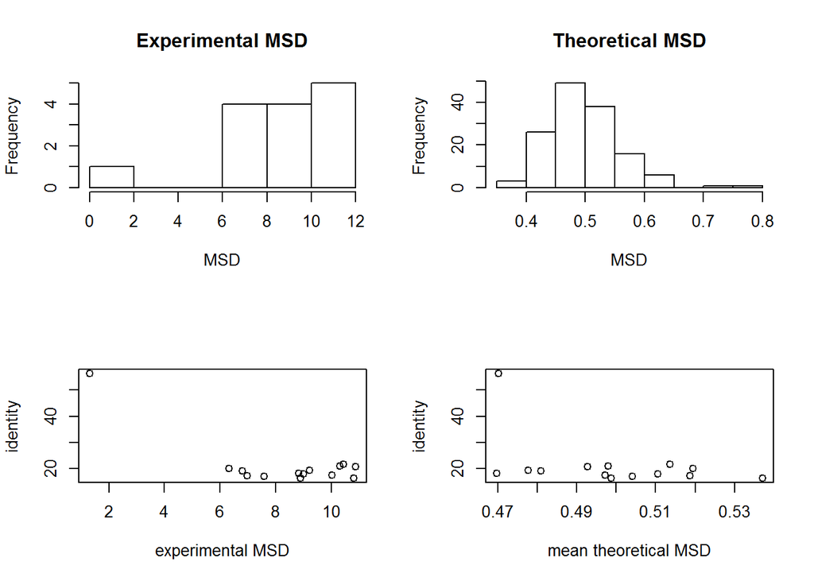

## Comparaciones

### RHO y AUC

Las distribuciones de *auc* y *rho* para cada conjunto se muestran a continuacion (azul= teorico, rojo = experimental)

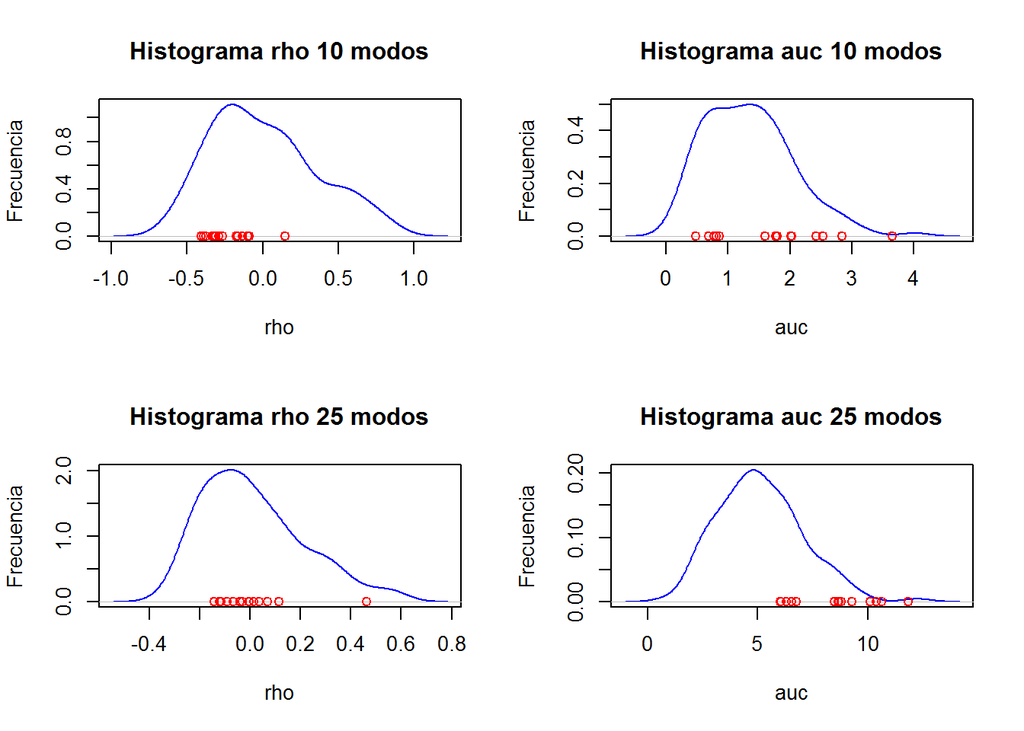

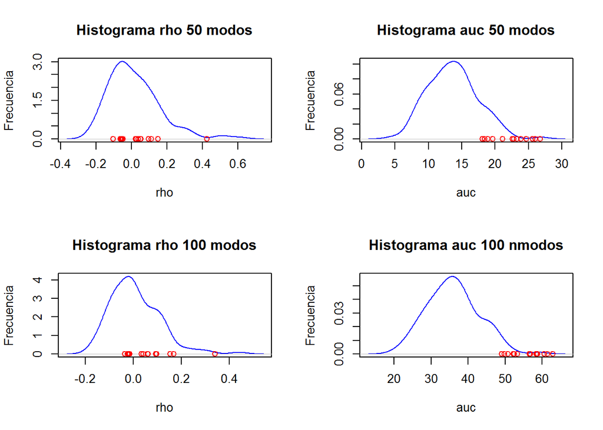

## Pn y Qn

Las distribuciones de *Pn* y *Qn* de los conjuntos son las siguientes:

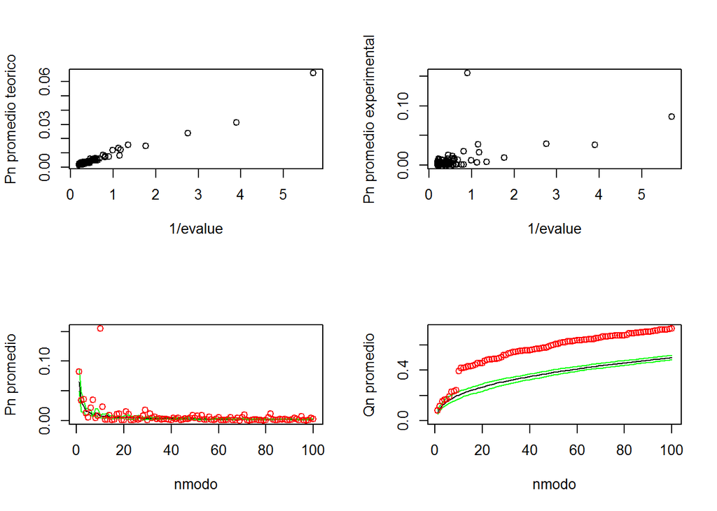

Negro: Teorico Rojo: Experimental Verdes: Cuartiles 0.05 y 0.95 de 10 grupos de 14 mutantes teoricas.